# Data Analytics for Business

## Sessions 4-5, Clustering and Segmentation

T. Evgeniou  
INSEAD

## Clustering and Segmentation

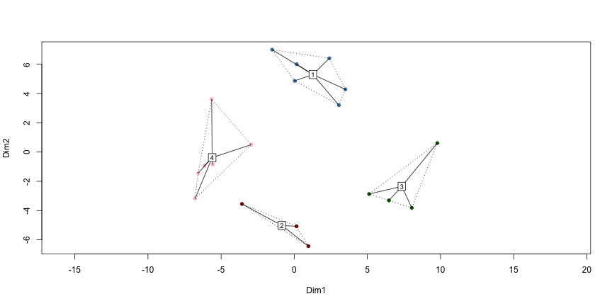

## What is Clustering and Segmentation?

Processes and tools to organize data in a few segments, with data being as similar as possible within each segment, and as different as possible across segments

## Example Usage

- Market Segmentation
- Co-Moving Asset Classes
- Geo-demographic segmentation
- Recommender Systems
- Text Mining

## A Segmentation Process

1. Confirm the data in metric
2. Decide whether to scale or standardize the data
3. Decide which variables to use for clustering
4. Define similarity or dissimilarity measures between observations
5. Visualize Individual Attributes and Pair-wise Distances between the Observations
6. Select the clustering method to use and decide how many clusters to have
7. Profile and interpret the clusters
8. Assess the robustness of our clusters

## Example Data: Market Research Survey

Size of data: 3872 observations with 68 variables each

V1: Shopping is fun (scale 1-7)

V2: Shopping is bad for your budget (scale 1-7)

V3: I combine shopping with eating out (scale 1-7)

V4: I try to get the best buys while shopping (scale 1-7)

V5: I don't care about shopping (scale 1-7)

V6: You can save lot of money by comparingprices (scale 1-7)

Income: the household income of the respondent (in dollars)

Mall.Visits: how often they visit the mall (scale 1-7)

## Data Standardization: Example Code

```r
ProjectData_segment_scaled=apply(ProjectData_segment,2, function(r) {
  if (sd(r)!=0) {
    res=(r-mean(r))/sd(r)
    } else {
      res=0*r; res
      }
  })
```

## Step 3. Decide which variables to use for clustering

The choice of the variables used for clustering is critically important

Tpically we use different variables for segmentation (the "segmentation variables") and different ones for profiling (the "profiling variables")

Remember: Segmentation is an iterative process

## Step 4. Define similarity or dissimilarity measures between observations

Defining what we mean when we say "similar" or "different" observations is a key part of cluster analysis which often requires a lot of contextual knowledge and creativity

There are literally thousands of rigorous mathematical definitions of distance between observations/vectors

The user can manually define such distance metrics

## Distances across our data using the Euclidean distance

Pairwise Distances between the first 5 observations using The Euclidean Distance Metric

| 1 | 2 | 3 | 4 | 5 |
| --- | --- | --- | --- | --- |
| 0.0 |  |  |  |  |
| 4.4 | 0.0 |  |  |  |
| 2.4 | 3.6 | 0.0 |  |  |
| 3.6 | 2.4 | 3.3 | 0.0 |  |
| 1.7 | 4.0 | 3.3 | 3.2 | 0.0 |

## Distances across our data using the Manhattan distance

Pairwise Distances between the first 5 observations using The Manhattan Distance Metric

| 1 | 2 | 3 | 4 | 5 |
| --- | --- | --- | --- | --- |
| 0.0 |  |  |  |  |
| 7.0 | 0.0 |  |  |  |
| 6.0 | 7.0 | 0.0 |  |  |
| 7.0 | 4.0 | 7.0 | 0.0 |  |
| 3.0 | 8.0 | 7.0 | 6.0 | 0.0 |

## Manually Defined Distances: an Example

```r
My_Distance_function<-function(x,y){sum(abs(x-y)>2)}
```

## Manually Defined Distances: an Example

Pairwise Distances between the first 5 observations using a simple manually defined Distance Metric

| 1 | 2 | 3 | 4 | 5 |
| --- | --- | --- | --- | --- |
| 0.0 |  |  |  |  |
| 1.0 | 0.0 |  |  |  |
| 0.0 | 1.0 | 0.0 |  |  |
| 1.0 | 0.0 | 0.0 | 0.0 |  |
| 0.0 | 1.0 | 0.0 | 0.0 | 0.0 |

## Step 5. Visualize Individual Attributes and Pair-wise Distances between the Observations

## Histogram of all pairwise distances

Distance Used: euclidean

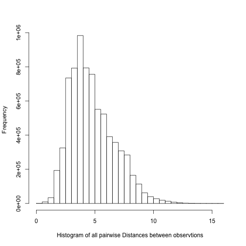

## Step 6. Select the clustering method to use and decide how many clusters to have

There are many clustering methods. Two common ones are:

- Hierarchical Methods
- Non-Hierarchical Methods (e.g. k-means)

We can plug-and-play (with CARE) this "black box" in our analysis